# Crash Course in Pandas

[Pandas](http://pandas.pydata.org) is a very popular Python package that provides data structures and data analysis tools. It includes tools for reading and writing various data formats, processing data sets in an efficient DataFrame object, and the ability to reshape, filter, index, and subset data easily.

This notebook is a quick introduction to some of the features of the Pandas package.

## Reading Data into DataFrames

The primary data structure in the Pandas package is the DataFrame. A DataFrame is a table-like object that contains named columns of data. Pandas provides readers for many different file types including CSV, Excel, SAS, HTML, etc. Since CSV is such a common format, let's look at reading a CSV file into a Pandas DataFrame.

First, we need to import the Pandas package. A very common convention is to import Pandas using a shortcut named of 'pd'. This is done with the following line.

```python
import pandas as pd
```

The function that reads CSV files into DataFrames is called `read_csv`. In the simplest form, you just supply it with a filename or URL. We have the SAS cars data set stored in github that we can point to directly. We'll use the `head` method to display just the first few records.

```python
df = pd.read_csv('https://raw.githubusercontent.com/'
                 'sassoftware/sas-viya-programming/master/data/cars.csv')
df.head()
```

|  | Make | Model | Type | Origin | DriveTrain | MSRP | Invoice | EngineSize | Cylinders | Horsepower | MPG_City | MPG_Highway | Weight | Wheelbase | Length |
| --- | --- | --- | --- | --- | --- | --- | --- | --- | --- | --- | --- | --- | --- | --- | --- |
| 0 | Acura | MDX | SUV | Asia | All | 36945.0 | 33337.0 | 3.5 | 6.0 | 265.0 | 17.0 | 23.0 | 4451.0 | 106.0 | 189.0 |
| 1 | Acura | RSX Type S 2dr | Sedan | Asia | Front | 23820.0 | 21761.0 | 2.0 | 4.0 | 200.0 | 24.0 | 31.0 | 2778.0 | 101.0 | 172.0 |
| 2 | Acura | TSX 4dr | Sedan | Asia | Front | 26990.0 | 24647.0 | 2.4 | 4.0 | 200.0 | 22.0 | 29.0 | 3230.0 | 105.0 | 183.0 |
| 3 | Acura | TL 4dr | Sedan | Asia | Front | 33195.0 | 30299.0 | 3.2 | 6.0 | 270.0 | 20.0 | 28.0 | 3575.0 | 108.0 | 186.0 |
| 4 | Acura | 3.5 RL 4dr | Sedan | Asia | Front | 43755.0 | 39014.0 | 3.5 | 6.0 | 225.0 | 18.0 | 24.0 | 3880.0 | 115.0 | 197.0 |

There are many more Pandas data readers that you read about on the [Pandas web site](http://pandas.pydata.org/pandas-docs/stable/io.html).

### Displaying Information about DataFrames

We have displayed the DataFrame above. We can get more information about the DataFrame using various properties and methods.

The list of column names can be displayed using the `columns` property.

```python
df.columns
```

```
Index(['Make', 'Model', 'Type', 'Origin', 'DriveTrain', 'MSRP', 'Invoice',
       'EngineSize', 'Cylinders', 'Horsepower', 'MPG_City', 'MPG_Highway',
       'Weight', 'Wheelbase', 'Length'],
      dtype='object')
```

The data types of the columns can be displayed using the `dtypes` property.

```python
df.dtypes
```

```
Make            object
Model           object
Type            object
Origin          object
DriveTrain      object
MSRP           float64
Invoice        float64
EngineSize     float64
Cylinders      float64
Horsepower     float64
MPG_City       float64
MPG_Highway    float64
Weight         float64
Wheelbase      float64
Length         float64
dtype: object
```

For general information about the DataFrame as a whole, you can use the `info` method.

```python
df.info()
```

```
<class 'pandas.core.frame.DataFrame'>
RangeIndex: 428 entries, 0 to 427
Data columns (total 15 columns):
Make           428 non-null object
Model          428 non-null object
Type           428 non-null object
Origin         428 non-null object
DriveTrain     428 non-null object
MSRP           428 non-null float64
Invoice        428 non-null float64
EngineSize     428 non-null float64
Cylinders      426 non-null float64
Horsepower     428 non-null float64
MPG_City       428 non-null float64
MPG_Highway    428 non-null float64
Weight         428 non-null float64
Wheelbase      428 non-null float64
Length         428 non-null float64
dtypes: float64(10), object(5)
memory usage: 50.2+ KB
```

Now that we know more about the columns and their data types, we can move on to subsetting DataFrames into other DataFrames or columns.

## Subsetting DataFrames

You can select columns from a DataFrame to create a DataFrame with fewer columns, or you can select a single column of data into a Series. The syntax used for this operation is Python's indexing syntax `[...]`.

If you index into a DataFrame using just the name of a column, you will get a Series back. If you index into a DataFrame using a list of names, you will get a DataFrame back.

```python
subdf = df[['Make', 'Model', 'Horsepower']]
subdf.head()
```

|  | Make | Model | Horsepower |
| --- | --- | --- | --- |
| 0 | Acura | MDX | 265.0 |
| 1 | Acura | RSX Type S 2dr | 200.0 |
| 2 | Acura | TSX 4dr | 200.0 |
| 3 | Acura | TL 4dr | 270.0 |
| 4 | Acura | 3.5 RL 4dr | 225.0 |

```python
model = df['Model']
model.head()
```

```
0               MDX
1    RSX Type S 2dr
2           TSX 4dr
3            TL 4dr
4        3.5 RL 4dr
Name: Model, dtype: object
```

In addition to selecting columns of data, DataFrames have more advanced ways of selecting data. We'll look at that in the next section.

### Row Indexing

Pandas DataFrames have an index associated both with rows and columns. We have seen the column index in the `columns` property above. We have also indexed into that collection using the column names. You can also index rows by position and label using the `iloc` and `loc` properties, respectively.

Currently, our cars DataFrame only has numeric row indexes, it doesn't have labels, so we'll start with `iloc`.

```python
df.iloc[3:7]
```

|  | Make | Model | Type | Origin | DriveTrain | MSRP | Invoice | EngineSize | Cylinders | Horsepower | MPG_City | MPG_Highway | Weight | Wheelbase | Length |
| --- | --- | --- | --- | --- | --- | --- | --- | --- | --- | --- | --- | --- | --- | --- | --- |
| 3 | Acura | TL 4dr | Sedan | Asia | Front | 33195.0 | 30299.0 | 3.2 | 6.0 | 270.0 | 20.0 | 28.0 | 3575.0 | 108.0 | 186.0 |
| 4 | Acura | 3.5 RL 4dr | Sedan | Asia | Front | 43755.0 | 39014.0 | 3.5 | 6.0 | 225.0 | 18.0 | 24.0 | 3880.0 | 115.0 | 197.0 |
| 5 | Acura | 3.5 RL w/Navigation 4dr | Sedan | Asia | Front | 46100.0 | 41100.0 | 3.5 | 6.0 | 225.0 | 18.0 | 24.0 | 3893.0 | 115.0 | 197.0 |
| 6 | Acura | NSX coupe 2dr manual S | Sports | Asia | Rear | 89765.0 | 79978.0 | 3.2 | 6.0 | 290.0 | 17.0 | 24.0 | 3153.0 | 100.0 | 174.0 |

As you can see above, we selected the row indexs from 3 to 7. In Python, numeric slices such as this include the first index, but do not include the last index. That is why you see row indexes 3, 4, 5, and 6 only in the result.

You can also select rows using a list of row indexes.

```python
df.iloc[[4, 5, 10]]
```

|  | Make | Model | Type | Origin | DriveTrain | MSRP | Invoice | EngineSize | Cylinders | Horsepower | MPG_City | MPG_Highway | Weight | Wheelbase | Length |
| --- | --- | --- | --- | --- | --- | --- | --- | --- | --- | --- | --- | --- | --- | --- | --- |
| 4 | Acura | 3.5 RL 4dr | Sedan | Asia | Front | 43755.0 | 39014.0 | 3.5 | 6.0 | 225.0 | 18.0 | 24.0 | 3880.0 | 115.0 | 197.0 |
| 5 | Acura | 3.5 RL w/Navigation 4dr | Sedan | Asia | Front | 46100.0 | 41100.0 | 3.5 | 6.0 | 225.0 | 18.0 | 24.0 | 3893.0 | 115.0 | 197.0 |
| 10 | Audi | A4 3.0 Quattro 4dr manual | Sedan | Europe | All | 33430.0 | 30366.0 | 3.0 | 6.0 | 220.0 | 17.0 | 26.0 | 3583.0 | 104.0 | 179.0 |

Arguably a more useful way of indexing Pandas DataFrames is using row labels. We can set a column as a row index using the `set_index` method. Then we can use those labels in the `loc` property for easy data selection.

```python
df = df.set_index('Model')
```

```python
df.head()
```

| Model | Make | Type | Origin | DriveTrain | MSRP | Invoice | EngineSize | Cylinders | Horsepower | MPG_City | MPG_Highway | Weight | Wheelbase | Length |
| --- | --- | --- | --- | --- | --- | --- | --- | --- | --- | --- | --- | --- | --- | --- |
| MDX | Acura | SUV | Asia | All | 36945.0 | 33337.0 | 3.5 | 6.0 | 265.0 | 17.0 | 23.0 | 4451.0 | 106.0 | 189.0 |
| RSX Type S 2dr | Acura | Sedan | Asia | Front | 23820.0 | 21761.0 | 2.0 | 4.0 | 200.0 | 24.0 | 31.0 | 2778.0 | 101.0 | 172.0 |
| TSX 4dr | Acura | Sedan | Asia | Front | 26990.0 | 24647.0 | 2.4 | 4.0 | 200.0 | 22.0 | 29.0 | 3230.0 | 105.0 | 183.0 |
| TL 4dr | Acura | Sedan | Asia | Front | 33195.0 | 30299.0 | 3.2 | 6.0 | 270.0 | 20.0 | 28.0 | 3575.0 | 108.0 | 186.0 |
| 3.5 RL 4dr | Acura | Sedan | Asia | Front | 43755.0 | 39014.0 | 3.5 | 6.0 | 225.0 | 18.0 | 24.0 | 3880.0 | 115.0 | 197.0 |

You'll see in the output above that the Model column is now displayed as a row index. We can use the values in that index in the `loc` property. This includes both single values, lists of values, or slices.

```python
df.loc['MDX']
```

```
Make           Acura
Type             SUV
Origin          Asia
DriveTrain       All
MSRP           36945
Invoice        33337
EngineSize       3.5
Cylinders          6
Horsepower       265
MPG_City          17
MPG_Highway       23
Weight          4451
Wheelbase        106
Length           189
Name: MDX, dtype: object
```

```python
df.loc[['TSX 4dr', 'TL 4dr']]
```

| Model | Make | Type | Origin | DriveTrain | MSRP | Invoice | EngineSize | Cylinders | Horsepower | MPG_City | MPG_Highway | Weight | Wheelbase | Length |
| --- | --- | --- | --- | --- | --- | --- | --- | --- | --- | --- | --- | --- | --- | --- |
| TSX 4dr | Acura | Sedan | Asia | Front | 26990.0 | 24647.0 | 2.4 | 4.0 | 200.0 | 22.0 | 29.0 | 3230.0 | 105.0 | 183.0 |
| TL 4dr | Acura | Sedan | Asia | Front | 33195.0 | 30299.0 | 3.2 | 6.0 | 270.0 | 20.0 | 28.0 | 3575.0 | 108.0 | 186.0 |

```python
df.loc['MDX':'TL 4dr']
```

| Model | Make | Type | Origin | DriveTrain | MSRP | Invoice | EngineSize | Cylinders | Horsepower | MPG_City | MPG_Highway | Weight | Wheelbase | Length |
| --- | --- | --- | --- | --- | --- | --- | --- | --- | --- | --- | --- | --- | --- | --- |
| MDX | Acura | SUV | Asia | All | 36945.0 | 33337.0 | 3.5 | 6.0 | 265.0 | 17.0 | 23.0 | 4451.0 | 106.0 | 189.0 |
| RSX Type S 2dr | Acura | Sedan | Asia | Front | 23820.0 | 21761.0 | 2.0 | 4.0 | 200.0 | 24.0 | 31.0 | 2778.0 | 101.0 | 172.0 |
| TSX 4dr | Acura | Sedan | Asia | Front | 26990.0 | 24647.0 | 2.4 | 4.0 | 200.0 | 22.0 | 29.0 | 3230.0 | 105.0 | 183.0 |
| TL 4dr | Acura | Sedan | Asia | Front | 33195.0 | 30299.0 | 3.2 | 6.0 | 270.0 | 20.0 | 28.0 | 3575.0 | 108.0 | 186.0 |

Note that when using slicing on labels, the endpoint for the slice is included. This is different than for row indexes.

### Indexing Both Rows and Columns

The `iloc` and `loc` properties can be used to subset both rows and columns simultaneously. However, the `iloc` property must only contain positional row and column index information, and `loc` must only contain row and column labels.

```python
df.iloc[1:5, 3:6]
```

| Model | DriveTrain | MSRP | Invoice |
| --- | --- | --- | --- |
| RSX Type S 2dr | Front | 23820.0 | 21761.0 |
| TSX 4dr | Front | 26990.0 | 24647.0 |
| TL 4dr | Front | 33195.0 | 30299.0 |
| 3.5 RL 4dr | Front | 43755.0 | 39014.0 |

```python
df.loc['MDX':'TL 4dr', 'MSRP':'Horsepower']
```

| Model | MSRP | Invoice | EngineSize | Cylinders | Horsepower |
| --- | --- | --- | --- | --- | --- |
| MDX | 36945.0 | 33337.0 | 3.5 | 6.0 | 265.0 |
| RSX Type S 2dr | 23820.0 | 21761.0 | 2.0 | 4.0 | 200.0 |
| TSX 4dr | 26990.0 | 24647.0 | 2.4 | 4.0 | 200.0 |
| TL 4dr | 33195.0 | 30299.0 | 3.2 | 6.0 | 270.0 |

If you want to mix positional and label information between rows and columns, you need to use the `ix` property.

```python
df.ix[2:6, 'MSRP':'Cylinders']
```

| Model | MSRP | Invoice | EngineSize | Cylinders |
| --- | --- | --- | --- | --- |
| TSX 4dr | 26990.0 | 24647.0 | 2.4 | 4.0 |
| TL 4dr | 33195.0 | 30299.0 | 3.2 | 6.0 |
| 3.5 RL 4dr | 43755.0 | 39014.0 | 3.5 | 6.0 |
| 3.5 RL w/Navigation 4dr | 46100.0 | 41100.0 | 3.5 | 6.0 |

Of course, the `ix` property also supports single values, lists of values, and slices for each component.

```python
df.ix[[1,2,5], ['Make', 'MSRP', 'Horsepower']]
```

| Model | Make | MSRP | Horsepower |
| --- | --- | --- | --- |
| RSX Type S 2dr | Acura | 23820.0 | 200.0 |
| TSX 4dr | Acura | 26990.0 | 200.0 |
| 3.5 RL w/Navigation 4dr | Acura | 46100.0 | 225.0 |

### Boolean Indexing

A more dynamic way of indexing DataFrames is to use boolean indexing. Rather than specifying explicit values for the index, we will use an expression to indicate which rows we want to select. The expression creates a boolean Series which indicates the rows to keep. Here is an example of a boolean series created by comparing the MSRP column to 40000.

```python
df['MSRP'] > 40000
```

```
Model
MDX                                 False
RSX Type S 2dr                      False
TSX 4dr                             False
TL 4dr                              False
3.5 RL 4dr                           True
3.5 RL w/Navigation 4dr              True
NSX coupe 2dr manual S               True
A4 1.8T 4dr                         False
A41.8T convertible 2dr              False
A4 3.0 4dr                          False
A4 3.0 Quattro 4dr manual           False
A4 3.0 Quattro 4dr auto             False
A6 3.0 4dr                          False
A6 3.0 Quattro 4dr                  False
A4 3.0 convertible 2dr               True
A4 3.0 Quattro convertible 2dr       True
A6 2.7 Turbo Quattro 4dr             True
A6 4.2 Quattro 4dr                   True
A8 L Quattro 4dr                     True
S4 Quattro 4dr                       True
RS 6 4dr                             True
TT 1.8 convertible 2dr (coupe)      False
TT 1.8 Quattro 2dr (convertible)    False
TT 3.2 coupe 2dr (convertible)       True
A6 3.0 Avant Quattro                 True
S4 Avant Quattro                     True
X3 3.0i                             False
X5 4.4i                              True
325i 4dr                            False
325Ci 2dr                           False
                                    ...
Tundra Regular Cab V6               False
Tundra Access Cab V6 SR5            False
Matrix XR                           False
Touareg V6                          False
Golf GLS 4dr                        False
GTI 1.8T 2dr hatch                  False
Jetta GLS TDI 4dr                   False
New Beetle GLS 1.8T 2dr             False
```

[output cut: 8 more lines]

```
Passat GLS 1.8T                     False
Passat W8                            True
XC90 T6                              True
S40 4dr                             False
S60 2.5 4dr                         False
S60 T5 4dr                          False
S60 R 4dr                           False
S80 2.9 4dr                         False
S80 2.5T 4dr                        False
C70 LPT convertible 2dr              True
C70 HPT convertible 2dr              True
S80 T6 4dr                           True
V40                                 False
XC70                                False
Name: MSRP, dtype: bool
```

As you can see, the values of the Series are all True or False. If we use that condition as an index value of a DataFrame, we'll get a new DataFrame containing only the rows where the condition was true.

```python
df[df['MSRP'] > 40000].head()
```

| Model | Make | Type | Origin | DriveTrain | MSRP | Invoice | EngineSize | Cylinders | Horsepower | MPG_City | MPG_Highway | Weight | Wheelbase | Length |
| --- | --- | --- | --- | --- | --- | --- | --- | --- | --- | --- | --- | --- | --- | --- |
| 3.5 RL 4dr | Acura | Sedan | Asia | Front | 43755.0 | 39014.0 | 3.5 | 6.0 | 225.0 | 18.0 | 24.0 | 3880.0 | 115.0 | 197.0 |
| 3.5 RL w/Navigation 4dr | Acura | Sedan | Asia | Front | 46100.0 | 41100.0 | 3.5 | 6.0 | 225.0 | 18.0 | 24.0 | 3893.0 | 115.0 | 197.0 |
| NSX coupe 2dr manual S | Acura | Sports | Asia | Rear | 89765.0 | 79978.0 | 3.2 | 6.0 | 290.0 | 17.0 | 24.0 | 3153.0 | 100.0 | 174.0 |
| A4 3.0 convertible 2dr | Audi | Sedan | Europe | Front | 42490.0 | 38325.0 | 3.0 | 6.0 | 220.0 | 20.0 | 27.0 | 3814.0 | 105.0 | 180.0 |
| A4 3.0 Quattro convertible 2dr | Audi | Sedan | Europe | All | 44240.0 | 40075.0 | 3.0 | 6.0 | 220.0 | 18.0 | 25.0 | 4013.0 | 105.0 | 180.0 |

```python
df[(df['MSRP'] > 40000) & (df['Cylinders'] > 8)].head()
```

| Model | Make | Type | Origin | DriveTrain | MSRP | Invoice | EngineSize | Cylinders | Horsepower | MPG_City | MPG_Highway | Weight | Wheelbase | Length |
| --- | --- | --- | --- | --- | --- | --- | --- | --- | --- | --- | --- | --- | --- | --- |
| Viper SRT-10 convertible 2dr | Dodge | Sports | USA | Rear | 81795.0 | 74451.0 | 8.3 | 10.0 | 500.0 | 12.0 | 20.0 | 3410.0 | 99.0 | 176.0 |
| Excursion 6.8 XLT | Ford | SUV | USA | All | 41475.0 | 36494.0 | 6.8 | 10.0 | 310.0 | 10.0 | 13.0 | 7190.0 | 137.0 | 227.0 |
| CL600 2dr | Mercedes-Benz | Sedan | Europe | Rear | 128420.0 | 119600.0 | 5.5 | 12.0 | 493.0 | 13.0 | 19.0 | 4473.0 | 114.0 | 196.0 |
| SL600 convertible 2dr | Mercedes-Benz | Sports | Europe | Rear | 126670.0 | 117854.0 | 5.5 | 12.0 | 493.0 | 13.0 | 19.0 | 4429.0 | 101.0 | 179.0 |
| Phaeton W12 4dr | Volkswagen | Sedan | Europe | Front | 75000.0 | 69130.0 | 6.0 | 12.0 | 420.0 | 12.0 | 19.0 | 5399.0 | 118.0 | 204.0 |

## Sorting

Sorting in Pandas DataFrames can be done according to the index or column values. The methods used to sort a DataFrame are `sort_index` for sorting by the index and `sort_values` for sorting by the data values.

Since we still have our index set as Model, let's sort by that first.

```python
df.sort_index().head()
```

| Model | Make | Type | Origin | DriveTrain | MSRP | Invoice | EngineSize | Cylinders | Horsepower | MPG_City | MPG_Highway | Weight | Wheelbase | Length |
| --- | --- | --- | --- | --- | --- | --- | --- | --- | --- | --- | --- | --- | --- | --- |
| 3.5 RL 4dr | Acura | Sedan | Asia | Front | 43755.0 | 39014.0 | 3.5 | 6.0 | 225.0 | 18.0 | 24.0 | 3880.0 | 115.0 | 197.0 |
| 3.5 RL w/Navigation 4dr | Acura | Sedan | Asia | Front | 46100.0 | 41100.0 | 3.5 | 6.0 | 225.0 | 18.0 | 24.0 | 3893.0 | 115.0 | 197.0 |
| 300M 4dr | Chrysler | Sedan | USA | Front | 29865.0 | 27797.0 | 3.5 | 6.0 | 250.0 | 18.0 | 27.0 | 3581.0 | 113.0 | 198.0 |
| 300M Special Edition 4dr | Chrysler | Sedan | USA | Front | 33295.0 | 30884.0 | 3.5 | 6.0 | 255.0 | 18.0 | 27.0 | 3650.0 | 113.0 | 198.0 |
| 325Ci 2dr | BMW | Sedan | Europe | Rear | 30795.0 | 28245.0 | 2.5 | 6.0 | 184.0 | 20.0 | 29.0 | 3197.0 | 107.0 | 177.0 |

Sorting by values is done by specify the columns that you want to sort by.

```python
df.sort_values(['MSRP', 'Horsepower']).head()
```

| Model | Make | Type | Origin | DriveTrain | MSRP | Invoice | EngineSize | Cylinders | Horsepower | MPG_City | MPG_Highway | Weight | Wheelbase | Length |
| --- | --- | --- | --- | --- | --- | --- | --- | --- | --- | --- | --- | --- | --- | --- |
| Rio 4dr manual | Kia | Sedan | Asia | Front | 10280.0 | 9875.0 | 1.6 | 4.0 | 104.0 | 26.0 | 33.0 | 2403.0 | 95.0 | 167.0 |
| Accent 2dr hatch | Hyundai | Sedan | Asia | Front | 10539.0 | 10107.0 | 1.6 | 4.0 | 103.0 | 29.0 | 33.0 | 2255.0 | 96.0 | 167.0 |
| Echo 2dr manual | Toyota | Sedan | Asia | Front | 10760.0 | 10144.0 | 1.5 | 4.0 | 108.0 | 35.0 | 43.0 | 2035.0 | 93.0 | 163.0 |
| Ion1 4dr | Saturn | Sedan | USA | Front | 10995.0 | 10319.0 | 2.2 | 4.0 | 140.0 | 26.0 | 35.0 | 2692.0 | 103.0 | 185.0 |
| Rio 4dr auto | Kia | Sedan | Asia | Front | 11155.0 | 10705.0 | 1.6 | 4.0 | 104.0 | 25.0 | 32.0 | 2458.0 | 95.0 | 167.0 |

You can also use the `ascending=` option to specify the order in which the columns should be sorted.

```python
df.sort_values(['MSRP', 'Horsepower'], ascending=[False, True]).head()
```

| Model | Make | Type | Origin | DriveTrain | MSRP | Invoice | EngineSize | Cylinders | Horsepower | MPG_City | MPG_Highway | Weight | Wheelbase | Length |
| --- | --- | --- | --- | --- | --- | --- | --- | --- | --- | --- | --- | --- | --- | --- |
| 911 GT2 2dr | Porsche | Sports | Europe | Rear | 192465.0 | 173560.0 | 3.6 | 6.0 | 477.0 | 17.0 | 24.0 | 3131.0 | 93.0 | 175.0 |
| CL600 2dr | Mercedes-Benz | Sedan | Europe | Rear | 128420.0 | 119600.0 | 5.5 | 12.0 | 493.0 | 13.0 | 19.0 | 4473.0 | 114.0 | 196.0 |
| SL600 convertible 2dr | Mercedes-Benz | Sports | Europe | Rear | 126670.0 | 117854.0 | 5.5 | 12.0 | 493.0 | 13.0 | 19.0 | 4429.0 | 101.0 | 179.0 |
| SL55 AMG 2dr | Mercedes-Benz | Sports | Europe | Rear | 121770.0 | 113388.0 | 5.5 | 8.0 | 493.0 | 14.0 | 21.0 | 4235.0 | 101.0 | 179.0 |
| CL500 2dr | Mercedes-Benz | Sedan | Europe | Rear | 94820.0 | 88324.0 | 5.0 | 8.0 | 302.0 | 16.0 | 24.0 | 4085.0 | 114.0 | 196.0 |

Keep in mind that the `sort_index` and `sort_values` methods return a new DataFrame with the sorting applied. If you want to sort a DataFrame in place, you need to specify the `inplace=True` option.

Let's reset the index before moving on to the next sections.

```python
df.reset_index(inplace=True)
```

## Doing Simple Statistics

Pandas DataFrames have many builtin methods for doing simple statistics. Probably the most common one is `describe`. It computes various basic statistics for the entire DataFrame.

```python
df.describe()
```

|  | MSRP | Invoice | EngineSize | Cylinders | Horsepower | MPG_City | MPG_Highway | Weight | Wheelbase | Length |
| --- | --- | --- | --- | --- | --- | --- | --- | --- | --- | --- |
| count | 428.000000 | 428.000000 | 428.000000 | 426.000000 | 428.000000 | 428.000000 | 428.000000 | 428.000000 | 428.000000 | 428.000000 |
| mean | 32774.855140 | 30014.700935 | 3.196729 | 5.807512 | 215.885514 | 20.060748 | 26.843458 | 3577.953271 | 108.154206 | 186.362150 |
| std | 19431.716674 | 17642.117750 | 1.108595 | 1.558443 | 71.836032 | 5.238218 | 5.741201 | 758.983215 | 8.311813 | 14.357991 |
| min | 10280.000000 | 9875.000000 | 1.300000 | 3.000000 | 73.000000 | 10.000000 | 12.000000 | 1850.000000 | 89.000000 | 143.000000 |
| 25% | 20334.250000 | 18866.000000 | 2.375000 | NaN | 165.000000 | 17.000000 | 24.000000 | 3104.000000 | 103.000000 | 178.000000 |
| 50% | 27635.000000 | 25294.500000 | 3.000000 | NaN | 210.000000 | 19.000000 | 26.000000 | 3474.500000 | 107.000000 | 187.000000 |
| 75% | 39205.000000 | 35710.250000 | 3.900000 | NaN | 255.000000 | 21.250000 | 29.000000 | 3977.750000 | 112.000000 | 194.000000 |
| max | 192465.000000 | 173560.000000 | 8.300000 | 12.000000 | 500.000000 | 60.000000 | 66.000000 | 7190.000000 | 144.000000 | 238.000000 |

The `describe` method has a couple of options to select different columns of data (`include=`) and the percentiles to compute (`percentiles=`). In the example below, we are selecting all of the columns and changing the displayed percentiles to 30% and 70% (50% is always displayed).

```python
df.describe(include='all', percentiles=[0.3, 0.7])
```

|  | Model | Make | Type | Origin | DriveTrain | MSRP | Invoice | EngineSize | Cylinders | Horsepower | MPG_City | MPG_Highway | Weight | Wheelbase | Length |
| --- | --- | --- | --- | --- | --- | --- | --- | --- | --- | --- | --- | --- | --- | --- | --- |
| count | 428 | 428 | 428 | 428 | 428 | 428.000000 | 428.000000 | 428.000000 | 426.000000 | 428.000000 | 428.000000 | 428.000000 | 428.000000 | 428.000000 | 428.000000 |
| unique | 425 | 38 | 6 | 3 | 3 | NaN | NaN | NaN | NaN | NaN | NaN | NaN | NaN | NaN | NaN |
| top | G35 4dr | Toyota | Sedan | Asia | Front | NaN | NaN | NaN | NaN | NaN | NaN | NaN | NaN | NaN | NaN |
| freq | 2 | 28 | 262 | 158 | 226 | NaN | NaN | NaN | NaN | NaN | NaN | NaN | NaN | NaN | NaN |
| mean | NaN | NaN | NaN | NaN | NaN | 32774.855140 | 30014.700935 | 3.196729 | 5.807512 | 215.885514 | 20.060748 | 26.843458 | 3577.953271 | 108.154206 | 186.362150 |
| std | NaN | NaN | NaN | NaN | NaN | 19431.716674 | 17642.117750 | 1.108595 | 1.558443 | 71.836032 | 5.238218 | 5.741201 | 758.983215 | 8.311813 | 14.357991 |
| min | NaN | NaN | NaN | NaN | NaN | 10280.000000 | 9875.000000 | 1.300000 | 3.000000 | 73.000000 | 10.000000 | 12.000000 | 1850.000000 | 89.000000 | 143.000000 |
| 30% | NaN | NaN | NaN | NaN | NaN | 22001.000000 | 20288.100000 | 2.400000 | NaN | 172.100000 | 18.000000 | 25.000000 | 3217.000000 | 104.000000 | 178.000000 |
| 50% | NaN | NaN | NaN | NaN | NaN | 27635.000000 | 25294.500000 | 3.000000 | NaN | 210.000000 | 19.000000 | 26.000000 | 3474.500000 | 107.000000 | 187.000000 |
| 70% | NaN | NaN | NaN | NaN | NaN | 35938.000000 | 32987.500000 | 3.600000 | NaN | 240.000000 | 21.000000 | 29.000000 | 3835.300000 | 111.000000 | 192.000000 |
| max | NaN | NaN | NaN | NaN | NaN | 192465.000000 | 173560.000000 | 8.300000 | 12.000000 | 500.000000 | 60.000000 | 66.000000 | 7190.000000 | 144.000000 | 238.000000 |

You can also select individual statistics using their own methods.

```python
df.min()
```

```
Model          3.5 RL 4dr
Make                Acura
Type               Hybrid
Origin               Asia
DriveTrain            All
MSRP                10280
Invoice              9875
EngineSize            1.3
Cylinders               3
Horsepower             73
MPG_City               10
MPG_Highway            12
Weight               1850
Wheelbase              89
Length                143
dtype: object
```

```python
df.median()
```

```
MSRP           27635.0
Invoice        25294.5
EngineSize         3.0
Cylinders          6.0
Horsepower       210.0
MPG_City          19.0
MPG_Highway       26.0
Weight          3474.5
Wheelbase        107.0
Length           187.0
dtype: float64
```

All of the above methods also work on individual columns, or subsets of columns.

```python
df['MSRP'].describe()
```

```
count       428.000000
mean      32774.855140
std       19431.716674
min       10280.000000
25%       20334.250000
50%       27635.000000
75%       39205.000000
max      192465.000000
Name: MSRP, dtype: float64
```

```python
df['MSRP'].min()
```

```
10280.0
```

```python
df[['MSRP', 'Horsepower']].describe()
```

|  | MSRP | Horsepower |
| --- | --- | --- |
| count | 428.000000 | 428.000000 |
| mean | 32774.855140 | 215.885514 |
| std | 19431.716674 | 71.836032 |
| min | 10280.000000 | 73.000000 |
| 25% | 20334.250000 | 165.000000 |
| 50% | 27635.000000 | 210.000000 |
| 75% | 39205.000000 | 255.000000 |
| max | 192465.000000 | 500.000000 |

## Grouping Data

Another common operation in analyzing data is grouping by variable values. This is primarily done using the `groupby` method of DataFrames.

```python
grpdf = df.groupby('Origin')
grpdf
```

```
<pandas.core.groupby.DataFrameGroupBy object at 0x7faed59673c8>
```

You'll notice that in this case the returned value is a `DataFrameGroupBy` object. Many of the methods available on a DataFrame will also work on the `DataFrameGroupBy` object.

```python
grpdf.describe()
```

| Origin |  | MSRP | Invoice | EngineSize | Cylinders | Horsepower | MPG_City | MPG_Highway | Weight | Wheelbase | Length |
| --- | --- | --- | --- | --- | --- | --- | --- | --- | --- | --- | --- |
| Asia | count | 158.000000 | 158.000000 | 158.000000 | 156.000000 | 158.000000 | 158.000000 | 158.000000 | 158.000000 | 158.000000 | 158.000000 |
|  | mean | 24741.322785 | 22602.177215 | 2.774051 | 5.185897 | 190.702532 | 22.012658 | 28.265823 | 3319.316456 | 105.886076 | 182.816456 |
|  | std | 11321.069675 | 9842.984880 | 0.902310 | 1.269008 | 59.392627 | 6.733307 | 6.770503 | 717.842132 | 7.735249 | 12.564148 |
|  | min | 10280.000000 | 9875.000000 | 1.300000 | 3.000000 | 73.000000 | 13.000000 | 17.000000 | 1850.000000 | 89.000000 | 153.000000 |
|  | 25% | 17208.000000 | 16271.500000 | 2.000000 | NaN | 142.000000 | 18.000000 | 25.000000 | 2751.500000 | 102.000000 | 175.000000 |
|  | 50% | 23032.500000 | 20949.500000 | 2.600000 | NaN | 187.500000 | 20.500000 | 27.000000 | 3280.000000 | 105.000000 | 183.500000 |
|  | 75% | 28787.500000 | 26645.000000 | 3.500000 | NaN | 233.750000 | 24.000000 | 31.000000 | 3706.750000 | 110.000000 | 191.000000 |
|  | max | 89765.000000 | 79978.000000 | 5.600000 | 8.000000 | 340.000000 | 60.000000 | 66.000000 | 5590.000000 | 140.000000 | 224.000000 |
| Europe | count | 123.000000 | 123.000000 | 123.000000 | 123.000000 | 123.000000 | 123.000000 | 123.000000 | 123.000000 | 123.000000 | 123.000000 |
|  | mean | 48349.796748 | 44395.081301 | 3.206504 | 6.235772 | 251.894309 | 18.731707 | 26.008130 | 3680.723577 | 106.447154 | 181.845528 |
|  | std | 25318.600464 | 23080.368888 | 1.037157 | 1.679585 | 80.738884 | 3.289509 | 4.167588 | 579.576871 | 6.690099 | 11.479870 |
|  | min | 16999.000000 | 15437.000000 | 1.600000 | 4.000000 | 100.000000 | 12.000000 | 14.000000 | 2524.000000 | 93.000000 | 143.000000 |
|  | 25% | 33837.500000 | 31287.500000 | 2.500000 | 5.000000 | 195.500000 | 17.000000 | 24.000000 | 3285.000000 | 102.000000 | 177.000000 |
|  | 50% | 40590.000000 | 37575.000000 | 3.000000 | 6.000000 | 225.000000 | 19.000000 | 26.000000 | 3585.000000 | 107.000000 | 182.000000 |
|  | 75% | 56382.500000 | 51042.500000 | 4.200000 | 8.000000 | 302.000000 | 20.000000 | 28.500000 | 3959.500000 | 110.000000 | 190.000000 |
|  | max | 192465.000000 | 173560.000000 | 6.000000 | 12.000000 | 493.000000 | 38.000000 | 46.000000 | 5423.000000 | 123.000000 | 204.000000 |
| USA | count | 147.000000 | 147.000000 | 147.000000 | 147.000000 | 147.000000 | 147.000000 | 147.000000 | 147.000000 | 147.000000 | 147.000000 |
|  | mean | 28377.442177 | 25949.340136 | 3.642857 | 6.108844 | 212.823129 | 19.074830 | 26.013605 | 3769.952381 | 112.020408 | 193.952381 |
|  | std | 11711.982506 | 10518.722194 | 1.194221 | 1.531090 | 63.748618 | 3.982992 | 5.396582 | 855.305524 | 8.788590 | 15.305265 |
|  | min | 10995.000000 | 10319.000000 | 1.600000 | 4.000000 | 103.000000 | 10.000000 | 12.000000 | 2348.000000 | 93.000000 | 150.000000 |
|  | 25% | 20315.000000 | 18927.000000 | 2.700000 | 5.000000 | 160.000000 | 17.000000 | 22.000000 | 3234.000000 | 106.000000 | 185.000000 |
|  | 50% | 25520.000000 | 23217.000000 | 3.600000 | 6.000000 | 200.000000 | 18.000000 | 26.000000 | 3606.000000 | 111.000000 | 194.000000 |
|  | 75% | 33767.500000 | 30778.000000 | 4.600000 | 8.000000 | 250.000000 | 21.000000 | 29.000000 | 4235.000000 | 115.000000 | 201.500000 |
|  | max | 81795.000000 | 74451.000000 | 8.300000 | 10.000000 | 500.000000 | 29.000000 | 37.000000 | 7190.000000 | 144.000000 | 238.000000 |

```python
grpdf[['MSRP', 'Horsepower']].describe(percentiles=[0.2, 0.8])
```

| Origin |  | MSRP | Horsepower |
| --- | --- | --- | --- |
| Asia | count | 158.000000 | 158.000000 |
|  | mean | 24741.322785 | 190.702532 |
|  | std | 11321.069675 | 59.392627 |
|  | min | 10280.000000 | 73.000000 |
|  | 20% | 15680.800000 | 130.000000 |
|  | 50% | 23032.500000 | 187.500000 |
|  | 80% | 30995.000000 | 240.000000 |
|  | max | 89765.000000 | 340.000000 |
| Europe | count | 123.000000 | 123.000000 |
|  | mean | 48349.796748 | 251.894309 |
|  | std | 25318.600464 | 80.738884 |
|  | min | 16999.000000 | 100.000000 |
|  | 20% | 32506.000000 | 184.000000 |
|  | 50% | 40590.000000 | 225.000000 |
|  | 80% | 64248.000000 | 315.000000 |
|  | max | 192465.000000 | 493.000000 |
| USA | count | 147.000000 | 147.000000 |
|  | mean | 28377.442177 | 212.823129 |
|  | std | 11711.982506 | 63.748618 |
|  | min | 10995.000000 | 103.000000 |
|  | 20% | 19099.000000 | 150.000000 |
|  | 50% | 25520.000000 | 200.000000 |
|  | 80% | 36079.000000 | 275.000000 |
|  | max | 81795.000000 | 500.000000 |

It is also possible to loop through all of the groupings using iteration in Python.

```python
for name, group in grpdf:
    print('=' * 35, name, '=' * 35)
    print('')
    print(group.head())
    print('')
```

```
=================================== Asia ===================================

            Model   Make   Type Origin DriveTrain     MSRP  Invoice  \
0             MDX  Acura    SUV   Asia        All  36945.0  33337.0
1  RSX Type S 2dr  Acura  Sedan   Asia      Front  23820.0  21761.0
2         TSX 4dr  Acura  Sedan   Asia      Front  26990.0  24647.0
3          TL 4dr  Acura  Sedan   Asia      Front  33195.0  30299.0
4      3.5 RL 4dr  Acura  Sedan   Asia      Front  43755.0  39014.0

   EngineSize  Cylinders  Horsepower  MPG_City  MPG_Highway  Weight  \
0         3.5        6.0       265.0      17.0         23.0  4451.0
1         2.0        4.0       200.0      24.0         31.0  2778.0
2         2.4        4.0       200.0      22.0         29.0  3230.0
3         3.2        6.0       270.0      20.0         28.0  3575.0
4         3.5        6.0       225.0      18.0         24.0  3880.0

   Wheelbase  Length
0      106.0   189.0
1      101.0   172.0
2      105.0   183.0
3      108.0   186.0
4      115.0   197.0

=================================== Europe ===================================

                        Model  Make   Type  Origin DriveTrain     MSRP  \
7                 A4 1.8T 4dr  Audi  Sedan  Europe      Front  25940.0
8      A41.8T convertible 2dr  Audi  Sedan  Europe      Front  35940.0
9                  A4 3.0 4dr  Audi  Sedan  Europe      Front  31840.0
10  A4 3.0 Quattro 4dr manual  Audi  Sedan  Europe        All  33430.0
11    A4 3.0 Quattro 4dr auto  Audi  Sedan  Europe        All  34480.0

    Invoice  EngineSize  Cylinders  Horsepower  MPG_City  MPG_Highway  Weight  \
7   23508.0         1.8        4.0       170.0      22.0         31.0  3252.0
8   32506.0         1.8        4.0       170.0      23.0         30.0  3638.0
9   28846.0         3.0        6.0       220.0      20.0         28.0  3462.0
10  30366.0         3.0        6.0       220.0      17.0         26.0  3583.0
11  31388.0         3.0        6.0       220.0      18.0         25.0  3627.0

    Wheelbase  Length
```

[output cut: 13 more lines]

```
50        Regal LS 4dr  Buick  Sedan    USA      Front  24895.0  22835.0

    EngineSize  Cylinders  Horsepower  MPG_City  MPG_Highway  Weight  \
46         4.2        6.0       275.0      15.0         21.0  4600.0
47         3.4        6.0       185.0      19.0         26.0  4024.0
48         3.1        6.0       175.0      20.0         30.0  3353.0
49         3.8        6.0       205.0      20.0         29.0  3567.0
50         3.8        6.0       200.0      20.0         30.0  3461.0

    Wheelbase  Length
46      113.0   193.0
47      112.0   187.0
48      109.0   195.0
49      112.0   200.0
50      109.0   196.0
```

There are far too many grouping features in Pandas to cover here. For more information, see the [Pandas Group By documentation](http://pandas.pydata.org/pandas-docs/stable/groupby.html).

## Plotting

There are several packages for creating plots in Python. These include [matplotlib](http://matplotlib.org), [seaborn](https://stanford.edu/~mwaskom/software/seaborn/), [bokeh](http://bokeh.pydata.org/en/latest/), plot.ly, or even Pandas itself. Many of these packages such as seaborn and the Pandas plotting features use matplotlib in the background. Packages like bokeh and plot.ly are primarily focused on graphics that are rendered in a web browser.

```python
%matplotlib inline
```

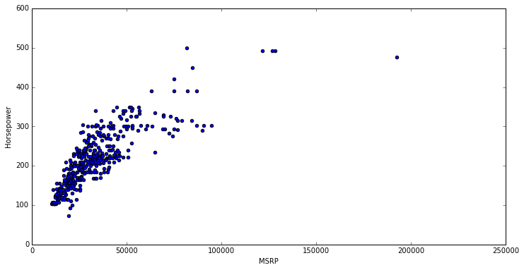

```python
df.plot(kind='scatter', x='MSRP', y='Horsepower', figsize=(12,6))
```

Using the cufflinks package, which is a DataFrame-style interface to plot.ly, we can create a graph that is rendered in the browser and includes interactive features.

```python
import cufflinks

# Configure cufflinks to render the graph locally.
cufflinks.go_offline()

df.iplot(kind='scatter', x='MSRP', y='Horsepower', mode='markers',
         size=8, dimensions=(750, 400))
```

[interactive chart not shown]

For more information on plotting features of DataFrames, see the [Pandas Visualization documentation](http://pandas.pydata.org/pandas-docs/stable/visualization.html).

## Conclusion

We've just covered the very basics of the Pandas package here. You should have enough to get started, but for more information, you should [see the official documentation](http://pandas.pydata.org/pandas-docs/stable/).